# Introducción a Python

### **Luis Hernando Vanegas (lhvanegasp@unal.edu.co)**

### **Luz Marina Rondón (lmrondonp@unal.edu.co)**

#### **Universidad Nacional de Colombia**

#### **Departamento de Estadística**

```python
import pandas as pd
!pip install pandasql
import pandasql as ps
import numpy as np
pd.options.display.float_format = '{:,.2f}'.format
```

```python
import os
os.chdir("C:\\Nano\\Docencia\\Curso")
```

```python
Municipios = pd.read_excel("Municipios.xlsx",dtype={'Dep': str, 'Depmun': str, 'Irural': float, 'Poblacion': float})
Municipios.info()
```

#### **Ejemplo 1**

Cuales variables del conjunto de datos *Municipios* tienen valores perdidos o missings?

```python
def missings(x):
            a = x.isna().sum()
            b = 100*x.isna().mean()
            c = pd.Series({"Missings": a,"%Missings": b})
            return(c)

Municipios.apply(missings)
```

#### **Ejemplo 2**

Se hace "limpieza" en los nombres de los municipios, es decir,

- Se eliminan caracteres especiales
- Se eliminan espacios al inicio y al final
- Se reemplazan espacios múltiples por sencillos
- Se escriben en letras minúsculas excepto en la inicial de cada palabra

```python
Municipios["Municipio2"] = (Municipios["Municipio"]
                            .str.lower()
                            .str.replace("[^a-záéíóúüñ ]","")
                            .str.replace(" +"," ")
                            .str.strip()
                            .str.title()
                           )
print(Municipios[["Municipio","Municipio2"]])

Municipios["Municipio"] = Municipios["Municipio2"]
Municipios = Municipios.drop(columns="Municipio2")
```

#### **Ejemplo 3**

Se hace "limpieza" en los nombres de los departamentos, es decir,

- Se eliminan caracteres especiales
- Se eliminan espacios al inicio y al final
- Se reemplazan espacios múltiples por sencillos
- Se escriben en letras minúsculas excepto en la inicial de cada palabra

```python
Municipios["Departamento2"] = (Municipios["Departamento"]
                               .str.lower()
                               .str.replace("[^a-záéíóúüñ ]","")
                               .str.replace(" +"," ")
                               .str.strip()
                               .str.title()
                              )
print(Municipios[["Departamento","Departamento2"]])

Municipios["Departamento"] = Municipios["Departamento2"]
Municipios = Municipios.drop(columns="Departamento2")
```

#### **Ejemplo 4**

Se crea la variable *Tipo* igual a "Capital" para la capital de cada departamento y "Otro" para el resto de los municipios.

```python
def tipo(x):
    if x[2:5]=="001" and x!="25001": return("Capital")
    else: return("Otros")
Municipios["Tipo"] = Municipios["Depmun"].apply(tipo)

Municipios.query("Tipo=='Capital'")
```

#### **Ejemplo 5**

Se crea la variable *denspobl* definida como el cociente entre *Poblacion* y *Superficie*. Se crea también la variable *Zona* igual a "Urbano" cuando *Irural* $ <= 40$ y "Rural" cuando *Irural* $ > 40$.

```python
Municipios["denspobl"] = Municipios["Poblacion"]/Municipios["Superficie"]

def zona(x):
    if x  > 40: return("Rural")
    if x <= 40: return("Urbano")
Municipios["Zona"] = Municipios["Irural"].apply(zona)

Municipios.head()
```

#### **Ejemplo 6**

Cálculo de algunas estadísticas descriptivas para las variables numéricas en el conjunto de datos *Municipios*.

```python
Municipios.describe()
```

#### **Ejemplo 7**

Cálculo de algunas estadísticas descriptivas (personalizadas) para las variables numéricas en el conjunto de datos *Municipios*.

```python
def summary(y):
    def numer(x):
        a = x.mean()
        b = x.std()
        c = x.median()
        d = x.skew()
        e = x.kurt()
        f = pd.Series({"Mean":a,"St.dev":b,"Median":c,"Skewness":d,"Kurtosis":e})
        return(f)
    numerics = y._get_numeric_data()
    if len(numerics.columns) > 0: return(numerics.apply(numer))

summary(Municipios)
```

# Tablas de frecuencia

```python
from mismacrospython import onewayfreq, twowayfreq
```

#### **Ejemplo 1**

Qué porcentaje del total representan los municipios del departamento de Norte de Santander? Cuantos municipios tiene el departamento del Valle del Cauca? Cuales son los cinco departamentos con mayor número de municipios? Qué porcentaje del total representan los municipios de estos cinco departamentos? Qué porcentaje de los municipios son rurales?

```python
onewayfreq(rows="Departamento",data=Municipios,ord="freq")
```

```python
onewayfreq(rows="Zona",data=Municipios,cum=False)
```

#### **Ejemplo 2**

Qué porcentaje de la población habita en el departamento del Meta? Cuantos habitantes tiene el departamento del Putumayo? Cuales son los cuatro departamentos con mayor número de habitantes? Qué porcentaje de la población habita en estos cuatro departamentos? Qué porcentaje de la población habita en municipios rurales?

```python
onewayfreq(rows="Departamento",weight="Poblacion",data=Municipios,ord="freq")
```

```python
onewayfreq(rows="Zona",weight="Poblacion",data=Municipios,cum=False)
```

#### **Ejemplo 3**

Cuales son los cinco municipios más/menos poblados del departamento de Bolívar? Qué porcentaje representan estos municipios del total de la población en el departamento? Qué porcentaje de la población del departamento habita en municipios rurales?

```python
onewayfreq(rows="Municipio",weight="Poblacion",data=Municipios,subset="Dep=='13'",ord="freq")
```

```python
onewayfreq(rows="Zona",weight="Poblacion",data=Municipios,subset="Dep=='13'",cum=False)
```

#### **Ejemplo 4**

Qué porcentaje de la superficie total de Colombia representa el departamento del Chocó? Cual es la superficie del departamento de Córdoba? Cuales son los cinco departamentos con mayor/menor superficie? Qué porcentaje representan estos cinco departamentos de la superficie total de Colombia?

```python
onewayfreq(rows="Departamento",weight="Superficie",data=Municipios,ord="freq")
```

```python
onewayfreq(rows="Departamento",weight="Superficie",data=Municipios,ord="-freq")
```

#### **Ejemplo 5**

Qué porcentaje de los municipios del departamento de La Guajira son rurales? Qué porcentaje de los municipios rurales están en el departamento de Vaupés?

```python
twowayfreq(rows="Departamento",columns="Zona",data=Municipios,ord="freq",rowpercent=True,colpercent=True)
```

#### **Ejemplo 6**

Qué porcentaje de la población del departamento de Boyacá está en municipios rurales? Qué porcentaje de la población total en municipios rurales está en el departamento de Antioquia?

```python
twowayfreq(rows="Departamento",columns="Zona",weight="Poblacion",data=Municipios,ord="freq")
```

#### **Ejemplo 7**

Qué porcentaje de la superficie del departamento de Nariño corresponde a municipios rurales? Qué porcentaje de la superficie total en municipios rurales está en el departamento de Atlántico?

```python
twowayfreq(rows="Departamento",columns="Zona",weight="Superficie",data=Municipios,ord="freq")
```

# Consulta, transformación y creación de conjuntos de datos

## Libreria pandasql

[figure not shown]

#### **Ejemplo 1**

*data.frame* con las variables *Departamento*, *Dep*, *Depmun*, *Municipio*, *Superficie* y *Poblacion* que incluye todos los municipios de los departamentos de Antioquia y Caldas con más de 20 mil habitantes y donde los mismos están ordenados con respecto a *Dep* y de mayor a menor con respecto a *Poblacion*.

```python
E1 = ps.sqldf("""select   Departamento, Dep, Depmun, Municipio, Superficie, Poblacion
                 from     Municipios
                 where    Dep in ('05','17') and Poblacion > 20000
                 order by Dep asc, Poblacion desc""")
E1.info()
```

```python
e1 = (Municipios
      .loc[:,["Departamento", "Dep", "Depmun", "Municipio", "Superficie", "Poblacion"]]
      .query("Poblacion > 20000 and Dep in ('05','17')")
      .sort_values(by=["Dep","Poblacion"],ascending=[True,False])
      .reset_index(drop=True)
     )

E1.equals(e1)
```

#### **Ejemplo 2**

*data.frame* con las variables *Departamento*, *Dep*, *Depmun*, *Municipio*, *Superficie* y *Poblacion* que incluye todos los municipios con superficies menores a 300 $km^2$ excepto los de Boyacá y Santander, y que están ordenados por *Dep* y de mayor a menor por *Poblacion*. Incluye una variable definida como "Baja" para los municipios con *denspobl* menor o igual a 30, "Alta" para los municipios con *denspobl* mayor a 85, y "Media" para los demás.

```python
E2 = ps.sqldf("""select   Departamento, Dep, Depmun, Municipio, Superficie,
                          Poblacion, case when denspobl <= 30 then 'Baja'
                                          when denspobl > 85 then 'Alta'
                                          else 'Media'
                                     end as denspoblC
                 from     Municipios
                 where    Dep not in ('15','68') and Superficie < 300
                 order by Dep asc, Poblacion desc""")

E2.info()
```

```python
e2 = Municipios
limites = [np.NINF,30,85,np.inf]
e2["denspoblC"] = pd.cut(e2["denspobl"],limites,labels=["Baja","Media","Alta"]).astype("object")
e2 = (e2
      .loc[:,["Departamento", "Dep", "Depmun", "Municipio", "Superficie", "Poblacion", "denspoblC"]]
      .query("Dep not in ('15','68') and Superficie < 300")
      .sort_values(by=["Dep","Poblacion"],ascending=[True,False])
      .reset_index(drop=True)
     )

E2.equals(e2)
```

#### **Ejemplo 3**

Existen dos o más municipios con el mismo *Depmun*?

```python
ps.sqldf("""select   Depmun, count(*) as count
            from     Municipios
            group by Depmun
            having   count > 1""")
```

```python
(Municipios
 .groupby("Depmun")["Depmun"]
 .agg(["count"]).reset_index()
 .query("count > 1")
)
```

#### **Ejemplo 4**

De los departamentos con dos o más municipios cual es el menos homogeneo (de acuerdo al rango) con respecto a la superficie de los municipios que lo componen?

```python
ps.sqldf("""select   Dep, Departamento, (max(Superficie)-min(Superficie)) as rango
            from     Municipios
            group by Dep, Departamento
            having   count(*) > 1
            order by rango desc
            limit    1""")
```

```python
def rango(x):
    return(x.max()- x.min())

(Municipios
 .groupby(["Dep","Departamento"])["Superficie"]
 .agg(["count",rango]).reset_index()
 .query("count > 1").drop(columns="count")
 .sort_values(by=["rango"],ascending=False).reset_index(drop=True)
 .head(n=1)
)
```

#### **Ejemplo 5**

```python
ps.sqldf("""select   Dep, Departamento, (max(Superficie)-min(Superficie)) as rango
            from     Municipios
            group by Dep, Departamento
            having   count(*) > 1
            order by rango
            limit    1""")
```

```python
 (Municipios.groupby(["Dep","Departamento"])["Superficie"]
  .agg(["count",rango]).reset_index()
  .query("count > 1").drop(columns="count")
  .sort_values(by=["rango"],ascending=True).reset_index(drop=True)
  .head(n=1)
 )
```

#### **Ejemplo 6**

*data.frame* con todos los departamentos, ordenados de mayor a menor con respecto a su población, que incluye la siguiente información: número de municipios, superficie, población, índice de ruralidad promedio ponderado por población, densidad poblacional, y una variable igual a "Grande" para los departamentos con población mayor a $1.5$ millones de habitantes, "Pequeño" para departamentos con población menor a $300$ mil habitantes, y "Mediano" para el resto.

```python
E6 = ps.sqldf("""select   Dep, Departamento, count(*) as nmunicipios, sum(Poblacion) as totpob,
                          sum(Superficie) as totsup, sum(Irural*Poblacion)/sum(Poblacion) as Irural,
                          sum(Poblacion)/sum(Superficie) as denspob,
                          case when sum(Poblacion) > 1500000 then 'Grande'
                               when sum(Poblacion) <= 300000 then 'Pequeño'
                               else 'Mediano'
                          end as totpobC
                 from     Municipios
                 group by Dep, Departamento
                 order by totpob desc""")

E6.info()
```

```python
Municipios["Irural2"] = Municipios["Irural"]*Municipios["Poblacion"]

e6 = (Municipios
      .groupby(["Dep","Departamento"])[["Depmun","Superficie","Poblacion","Irural2"]]
      .agg(nmunicipios=("Depmun","count"),totpob=("Poblacion","sum"),totsup=("Superficie","sum"),
           Irural=("Irural2","sum")).reset_index()
      .eval("Irural = Irural/totpob")
      .eval("denspob = totpob/totsup")
      .sort_values(by=["totpob"],ascending=False)
      .reset_index(drop=True)
     )

limites = [np.NINF,300000,1500000,np.inf]
e6["totpobC"] = pd.cut(e6["totpob"],limites,labels=["Pequeño","Mediano","Grande"]).astype("object")

Municipios = Municipios.drop(columns="Irural2")
E6.equals(e6)
```

#### **Ejemplo 7**

Cual es la región con la mayor superficie?

```python
ps.sqldf("""select   Region
            from     Municipios
            group by Region
            order by sum(Superficie) desc
            limit    1""")
```

```python
(Municipios
 .groupby(["Region"])["Superficie"]
 .agg(["sum"]).reset_index()
 .sort_values(by=["sum"],ascending=False).drop(columns="sum").reset_index(drop=True)
 .head(n=1)
)
```

#### **Ejemplo 8**

*data.frame* con todos los departamentos, ordenados de mayor a menor con respecto a su población, que incluye la siguiente información: número de municipios, superficie, población, densidad poblacional, todo referente a los municipios con índice de ruralidad mayor a 60.

```python
E8 = ps.sqldf("""select   Dep, Departamento, count(*) as nmunicipios, sum(Poblacion) as totpob,
                          sum(Superficie) as totsup, sum(Poblacion)/sum(Superficie) as denspob
                 from     Municipios
                 where    Irural > 60
                 group by Dep, Departamento
                 order by totpob desc""")
E8.info()
```

```python
e8 = (Municipios
      .query("Irural > 60")
      .groupby(["Dep","Departamento"])[["Depmun","Superficie","Poblacion"]]
      .agg(nmunicipios=("Depmun","count"),totpob=("Poblacion","sum"),totsup=("Superficie","sum")).reset_index()
      .sort_values(by=["totpob"],ascending=False)
      .reset_index(drop=True))

e8["denspob"] = e8["totpob"]/e8["totsup"]

E8.equals(e8)
```

#### **Ejemplo 9**

Cual es la región con el mayor número de departamentos?

```python
ps.sqldf("""select   Region
            from     Municipios
            group by Region
            order by count(distinct Dep) desc
            limit    1""")
```

```python
         (Municipios.groupby(["Region"])["Dep"]
          .agg(["nunique"]).reset_index()
          .sort_values(by=["nunique"],ascending=False).drop(columns="nunique")
          .head(n=1)
         )
```

#### **Ejemplo 10**

*data.frame* con todos los departamentos con al menos 650 mil habitantes y al menos 10 mil $km^2$ de superficie, ordenados de mayor a menor con relación a su densidad poblacional, y que incluye la siguiente información: número de municipios, superficie, población y densidad poblacional.

```python
E10 = ps.sqldf("""select   Dep, Departamento, count(*) as nmunicipios, sum(Poblacion) as totpob,
                           sum(Superficie) as totsup, sum(Poblacion)/sum(Superficie) as denspob
                  from     Municipios
                  group by Dep, Departamento
                  having   totpob >= 650000 and totsup >= 10000
                  order by denspob desc""")
E10.info()
```

```python
e10 = (Municipios
       .groupby(["Dep","Departamento"])[["Depmun","Superficie","Poblacion"]]
       .agg(nmunicipios=("Depmun","count"),totpob=("Poblacion","sum"),totsup=("Superficie","sum")).reset_index()
       .eval("denspob = totpob/totsup")
       .query("totpob >= 650000 and totsup >= 10000")
       .sort_values(by=["denspob"],ascending=False).reset_index(drop=True)
      )

E10.equals(e10)
```

#### **Ejemplo 11**

*data.frame* con todos los departamentos con al menos 650 mil habitantes y al menos 10 mil $km^2$ de superficie, ordenados de mayor a menor con relación a su densidad poblacional, y que incluye la siguiente información: número de municipios, superficie, población, y densidad poblacional, todo referente a municipios con índice de ruralidad mayor a 40.

```python
E11 = ps.sqldf("""select   Dep, Departamento, count(*) as nmunicipios, sum(Poblacion) as totpob,
                           sum(Superficie) as totsup, sum(Poblacion)/sum(Superficie) as denspob
                  from     Municipios
                  where    Irural > 40
                  group by Dep, Departamento
                  having   totpob >= 650000 and totsup >= 10000
                  order by denspob desc""")
E11.info()
```

```python
e11 = (Municipios
       .query("Irural > 40")
       .groupby(["Dep","Departamento"])[["Depmun","Superficie","Poblacion"]]
       .agg(nmunicipios=("Depmun","count"),totpob=("Poblacion","sum"),totsup=("Superficie","sum")).reset_index()
       .eval("denspob = totpob/totsup")
       .query("totpob >= 650000 and totsup >= 10000")
       .sort_values(by=["denspob"],ascending=False).reset_index(drop=True)
      )

E11.equals(e11)
```

#### **Ejemplo 12**

Existen dos o más municipios con el mismo nombre? Cuantos? Cuales? En qué departamentos están ubicados?

```python
Repetidos = ps.sqldf("""select   Municipio, count(*) as veces
                        from     Municipios
                        group by Municipio
                        having   veces > 1
                        order by veces desc""")

E12 = ps.sqldf("""select   Municipio, Departamento, Dep, Depmun
                  from     Municipios
                  where    Municipio in (select Municipio
                                         from   Repetidos)
                  order by Municipio, Departamento""")

E12.info()
```

```python
Repetidos = (Municipios
             .groupby("Municipio")
             .agg(reps=("Municipio","count")).reset_index()
             .query("reps > 1")
             .sort_values(by=["reps"],ascending=False)
            )
reps = Repetidos["Municipio"]

e12 = (Municipios
       .loc[:,["Municipio", "Departamento", "Dep", "Depmun"]]
       .query("Municipio in @reps")
       .sort_values(by=["Municipio", "Departamento"],ascending=[True,True]).reset_index(drop=True)
      )

E12.equals(e12)
```

#### **Ejemplo 13**

Existen dos o más municipios con el mismo nombre que hacen parte de la misma región? Cuantos? Cuales?

```python
Municipios["regmun"] = Municipios["Region"] + Municipios["Municipio"]

Repetidos = ps.sqldf("""select   regmun, count(*) as veces
                        from     Municipios
                        group by Region, Municipio
                        having   veces > 1
                        order by veces desc""")

E13 = ps.sqldf("""select   Municipio, Region, Departamento, Dep, Depmun
                  from     Municipios
                  where    regmun in (select regmun
                                      from   Repetidos)
                  order by Municipio asc, Region asc""")

E13.info()
```

```python
Repetidos = (Municipios
             .groupby("regmun")
             .agg(reps=("regmun","count")).reset_index()
             .query("reps > 1")
             .sort_values(by=["reps"],ascending=False)
            )
reps = Repetidos["regmun"]

e13 = (Municipios
       .query("regmun in @reps")
       .loc[:,["Municipio", "Region", "Departamento", "Dep", "Depmun"]]
       .sort_values(by=["Municipio", "Region"],ascending=[True,True])
       .reset_index(drop=True)
      )

Municipios = Municipios.drop(columns="regmun")
E13.equals(e13)
```

#### **Ejemplo 14**

*data.frame* con los municipios cuyos nombres inician con "A" o terminan con "o".

```python
E14 = ps.sqldf("""select   Dep, Departamento, Municipio, Depmun
                  from     Municipios
                  where    Municipio like 'A%' or Municipio like '%o'
                  order by Depmun""")

E14.info()
```

```python
e14 = (Municipios
       .query("Municipio.str.contains('^A|o$')",engine="python")
       .loc[:,["Dep", "Departamento", "Municipio", "Depmun"]]
       .sort_values(by=["Depmun"],ascending=True)
       .reset_index(drop=True)
      )

E14.equals(e14)
```

#### **Ejemplo 15**

*data.frame* con los municipios cuyos nombres inician con "A" y terminan con "o".

```python
E15 = ps.sqldf("""select   Dep, Departamento, Municipio, Depmun
                  from     Municipios
                  where    Municipio like 'A%o'
                  order by Depmun""")
E15.info()
```

```python
e15 = (Municipios
       .query("Municipio.str.contains('^A.*o$')",engine="python")
       .loc[:,["Dep", "Departamento", "Municipio", "Depmun"]]
       .sort_values(by=["Depmun"],ascending=True)
       .reset_index(drop=True)
      )

E15.equals(e15)
```

#### **Ejemplo 16**

*data.frame* con los municipios cuyo nombre tiene a la letra "e" en las posiciones 2 y 4.

```python
E16 = ps.sqldf("""select   Dep, Departamento, Municipio, Depmun
                  from     Municipios
                  where    Municipio like '_e_e%'
                  order by Depmun""")
E16.info()
```

```python
e16 = (Municipios
       .query("Municipio.str.contains('^.{1}e.{1}e.*')",engine="python")
       .loc[:,["Dep", "Departamento", "Municipio", "Depmun"]]
       .sort_values(by=["Depmun"],ascending=True)
       .reset_index(drop=True)
      )

E16.equals(e16)
```

#### **Ejemplo 17**

*data.frame* con los municipios cuyos nombres constan de más de una palabra.

```python
E17 = ps.sqldf("""select   Dep, Departamento, Municipio, Depmun
                  from     Municipios
                  where    Municipio like '% %'
                  order by Depmun""")
E17.info()
```

```python
e17 = (Municipios
       .query("Municipio.str.contains('.* .*')",engine="python")
       .loc[:,["Dep", "Departamento", "Municipio", "Depmun"]]
       .sort_values(by=["Depmun"],ascending=True)
       .reset_index(drop=True)
      )

E17.equals(e17)
```

[figure not shown]

```python
A = pd.DataFrame({"id":[1,2,2,3],"cod":[23,65,60,87],"name":["Leia","Luke","Yoda","Hank"]})
B = pd.DataFrame({"id":[2,3,4],"cod":[65,87,29],"age":[23,20,25]})
A
B

ps.sqldf("""select *
            from     A inner join B on (A.id=B.id and A.cod=B.cod)""")

ps.sqldf("""select *
            from     B inner join A on (B.id=A.id and B.cod=A.cod)""")

ps.sqldf("""select *
            from     A left join B on (A.id=B.id and A.cod=B.cod)""")

ps.sqldf("""select *
            from     B left join A on (B.id=A.id and B.cod=A.cod)""")
```

#### **Ejemplo 18**

Cuantos y cuales municipios tienen al menos una estación de monitoreo climático?

```python
Estaciones = pd.read_excel("Estaciones.xlsx",dtype={'CODIGO': str, 'Depmun': str})
Estaciones.info()

E18 = ps.sqldf("""select distinct Depmun
                  from   Estaciones""")
E18.info()
```

#### **Ejemplo 19**

*data.frame* con todos los municipios del país, que incluye una variable que informa el número de estaciones de monitoreo climático con que cuenta cada municipio.

```python
Emon = ps.sqldf("""select   Depmun, count(*) as nem
                   from     Estaciones
                   group by Depmun""")

E19 = ps.sqldf("""select Municipios.*, case when nem is null then 0.0
                                            else nem
                                       end as nest
                  from   Municipios left join Emon on (Municipios.Depmun = Emon.Depmun)""")
E19.info()
```

```python
Emon = (Estaciones
        .groupby("Depmun")["CODIGO"]
        .agg(nem=("CODIGO","count")).reset_index()
       )

e19 = (Municipios
      .merge(Emon,left_on="Depmun",right_on="Depmun",how="left")
      .eval("nest = nem.fillna(0)",engine="python").drop(columns="nem")
      )

E19.equals(e19)
```

#### **Ejemplo 20**

Existen municipios que no tienen ninguna estación de monitoreo climático? Cuantos? Cuales?

```python
E20 = ps.sqldf("""select   Municipios.*
              from     Municipios left join Emon on (Municipios.Depmun = Emon.Depmun)
              where    nem is NULL
              order by Depmun""")

E20a = ps.sqldf("""select   Municipios.*
               from     Municipios
               where    Depmun not in (select Depmun
                                       from   Estaciones)
               order by Depmun""")

E20.equals(E20a)
E20.info()
```

```python
e20 = (Municipios
       .merge(Emon,left_on="Depmun",right_on="Depmun",how="left")
       .query("nem.isnull()",engine="python")
       .sort_values(by=["Depmun"],ascending=True).reset_index(drop=True).drop(columns="nem")
      )

emons = Emon["Depmun"]
e20a = (Municipios
        .query("Depmun not in @emons")
        .sort_values(by=["Depmun"],ascending=True).reset_index(drop=True)
       )

print(e20.equals(e20a))
E20.equals(e20)
```

#### **Ejemplo 21**

Copia de Estaciones que solo considera estaciones de monitoreo localizadas como máximo a 2000 metros de altura sobre el nivel del mar, y que incluye los nombres del municipio y del departamento donde están ubicadas las estaciones.

```python
E21 = ps.sqldf("""select   Estaciones.*, Municipio, Departamento, Dep
              from     Estaciones inner join Municipios on (Estaciones.Depmun = Municipios.Depmun)
              where    elev <= 2000
              order by Depmun, codigo""")

E21.info()
```

```python
e21 = (Estaciones
       .merge(Municipios[["Municipio", "Departamento", "Dep","Depmun"]],left_on="Depmun",right_on="Depmun",how="left")
       .query("ELEV <= 2000")
       .sort_values(by=["Depmun","CODIGO"],ascending=[True,True])
       .reset_index(drop=True)
      )

E21.equals(e21)
```

```python
import numpy as np
import seaborn as sns
import matplotlib.pyplot as plt
```

```python
Advertising = pd.read_excel("Advertising.xlsx")
Advertising.info()
```

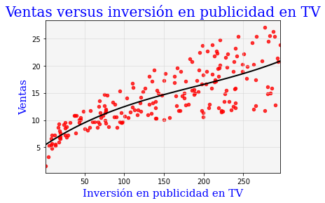

```python
fig = sns.regplot(x="TV",y="sales",data=Advertising,order=3,marker="o",
                  scatter_kws={"s":20,"color":"red"},line_kws={"ls":"solid","lw":2,"color":"black"},ci=None)
plt.xlabel("Inversión en publicidad en TV",fontdict={"family":"serif","color":"blue","size":15})
plt.ylabel("Ventas",fontdict={"family":"serif","color":"blue","size":15})
plt.title("Ventas versus inversión en publicidad en TV",
          fontdict={"family":"serif","color":"blue","size":20},loc="center")
plt.grid(axis="both",color="lightgray",ls="solid",lw=0.5)
fig.patch.set_facecolor("whitesmoke")
plt.show(fig)
```

```python
cats = 3
bins = Advertising["radio"].quantile(np.arange(0,cats+1)/cats)
Advertising["radioC"] = pd.cut(Advertising["radio"],bins,labels=["Baja","Media","Alta"])
```

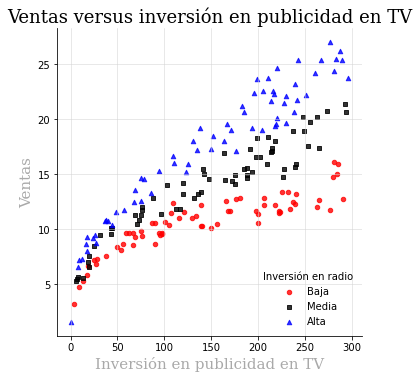

```python
fig = sns.lmplot(x="TV",y="sales",data=Advertising,order=3,hue="radioC",markers=["o","s","^"],
                 palette=dict(Baja="red",Media="black",Alta="blue"),
                 scatter_kws={"s":20},ci=None,legend=False,fit_reg=False,
                 line_kws={"ls":"solid","lw":2})
plt.legend(loc='lower right',title="Inversión en radio",frameon=False,ncol=1)
plt.xlabel("Inversión en publicidad en TV",fontdict={"family":"serif","color":"darkgrey","size":15})
plt.ylabel("Ventas",fontdict={"family":"serif","color":"darkgrey","size":15})
plt.title("Ventas versus inversión en publicidad en TV",
          fontdict={"family":"serif","color":"black","size":18},loc="center")
plt.grid(axis="both",color="lightgray",ls="solid",lw=0.5)
plt.show(fig)
```

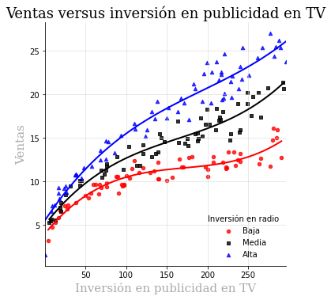

```python
fig = sns.lmplot(x="TV",y="sales",data=Advertising,order=3,hue="radioC",markers=["o","s","^"],
                 palette=dict(Baja="red",Media="black",Alta="blue"),
                 scatter_kws={"s":20},ci=None,legend=False,
                 line_kws={"ls":"solid","lw":2})
plt.legend(loc='lower right',title="Inversión en radio",frameon=False,ncol=1)
plt.xlabel("Inversión en publicidad en TV",fontdict={"family":"serif","color":"darkgrey","size":15})
plt.ylabel("Ventas",fontdict={"family":"serif","color":"darkgrey","size":15})
plt.title("Ventas versus inversión en publicidad en TV",
          fontdict={"family":"serif","color":"black","size":18},loc="center")
plt.grid(axis="both",color="lightgray",ls="solid",lw=0.5)
plt.show(fig)
```

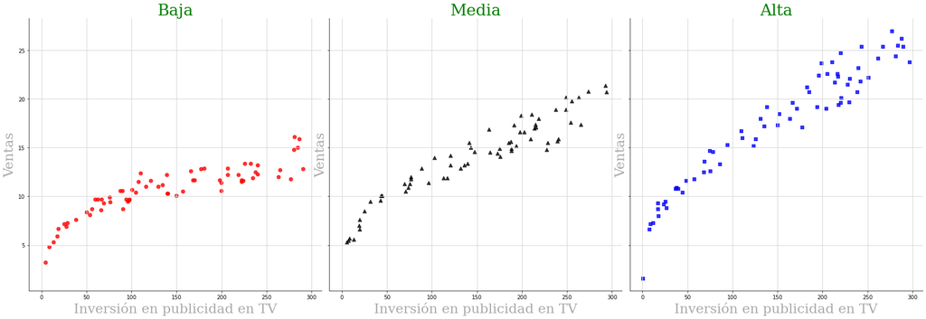

```python
g = sns.FacetGrid(data=Advertising,col="radioC",hue="radioC",sharey=True,height=8,
                  hue_kws=dict(marker=["o","^","s"],color=["red","black","blue"]))
g.map(sns.regplot,"TV","sales",order=3,scatter_kws={"s":45},line_kws={"ls":"solid","lw":1},ci=None,fit_reg=False)
axes = g.axes.flatten()
titulos = ["Baja","Media","Alta"]
for ax in np.arange(0,len(titulos)):
    axes[ax].set_xlabel("Inversión en publicidad en TV",fontdict={"family":"serif","color":"darkgrey","size":25})
    axes[ax].set_ylabel("Ventas",fontdict={"family":"serif","color":"darkgrey","size":25})
    axes[ax].set_title(titulos[ax],fontdict={"family":"serif","color":"green","size":30},loc="center")
    axes[ax].grid(axis="both",color="lightgray",ls="solid",lw=1)
```

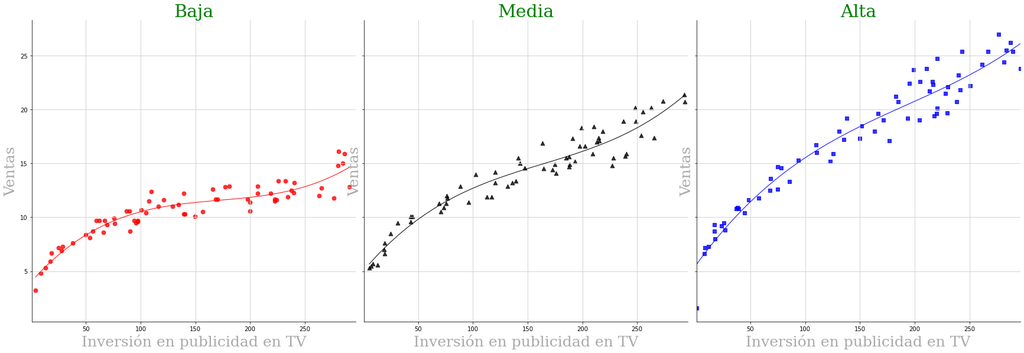

```python
g = sns.FacetGrid(data=Advertising,col="radioC",hue="radioC",sharey=True,height=8,
                  hue_kws=dict(marker=["o","^","s"],color=["red","black","blue"]))
g.map(sns.regplot,"TV","sales",order=3,scatter_kws={"s":45},line_kws={"ls":"solid","lw":1},ci=None)
axes = g.axes.flatten()
titulos = ["Baja","Media","Alta"]
for ax in np.arange(0,len(titulos)):
    axes[ax].set_xlabel("Inversión en publicidad en TV",fontdict={"family":"serif","color":"darkgrey","size":25})
    axes[ax].set_ylabel("Ventas",fontdict={"family":"serif","color":"darkgrey","size":25})
    axes[ax].set_title(titulos[ax],fontdict={"family":"serif","color":"green","size":30},loc="center")
    axes[ax].grid(axis="both",color="lightgray",ls="solid",lw=1)
```

```python
cats = 3
bins = Advertising["TV"].quantile(np.arange(0,cats+1)/cats)
Advertising["TVC"] = pd.cut(Advertising["TV"],bins,labels=["Baja","Media","Alta"])
```

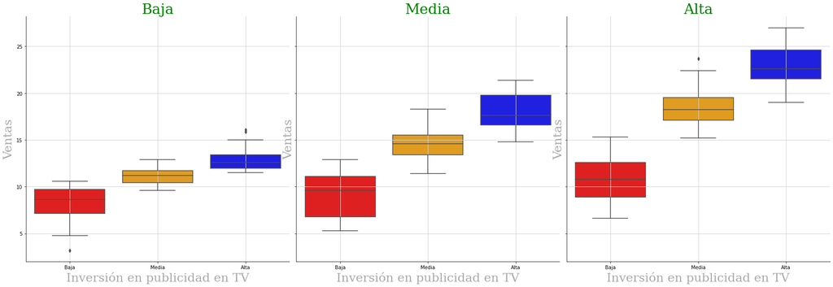

```python
g = sns.FacetGrid(data=Advertising,col="radioC",sharey=True,height=8)
g.map(sns.boxplot,"TVC","sales",order=titulos,palette=dict(Baja="red",Media="orange",Alta="blue"),linewidth=1.5)
axes = g.axes.flatten()
for ax in np.arange(0,len(titulos)):
    axes[ax].set_xlabel("Inversión en publicidad en TV",fontdict={"family":"serif","color":"darkgrey","size":25})
    axes[ax].set_ylabel("Ventas",fontdict={"family":"serif","color":"darkgrey","size":25})
    axes[ax].set_title(titulos[ax],fontdict={"family":"serif","color":"green","size":30},loc="center")
    axes[ax].grid(axis="both",color="lightgray",ls="solid",lw=1)
```

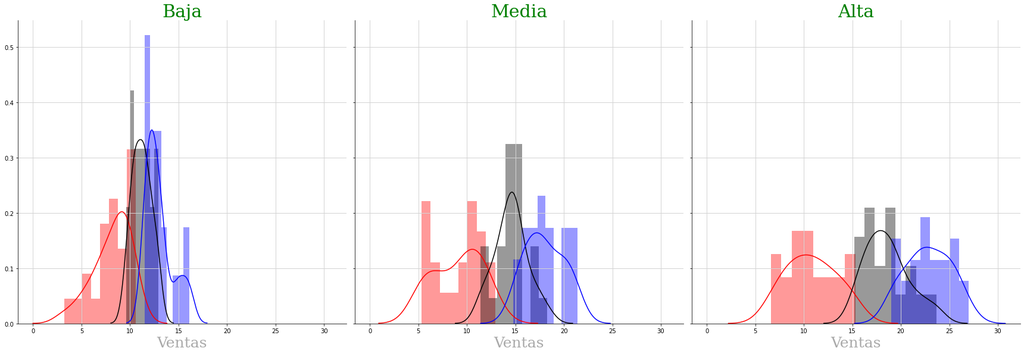

```python
g = sns.FacetGrid(data=Advertising,col="radioC",hue="TVC",sharey=True,height=8,
                 hue_kws=dict(color=["red","black","blue"]))
g.map(sns.distplot,"sales",norm_hist=True,kde=True,bins=8)
axes = g.axes.flatten()
for ax in np.arange(0,len(titulos)):
    axes[ax].set_xlabel("Ventas",fontdict={"family":"serif","color":"darkgrey","size":25})
    axes[ax].set_title(titulos[ax],fontdict={"family":"serif","color":"green","size":30},loc="center")
    axes[ax].grid(axis="both",color="lightgray",ls="solid",lw=1)
```

```python
#sns.get_dataset_names()
cars = sns.load_dataset("mpg")
cars.loc[cars["origin"]=="usa","Origen"] = "Estados Unidos"
cars.loc[cars["origin"]!="usa","Origen"] = "Japón y Europa"
```

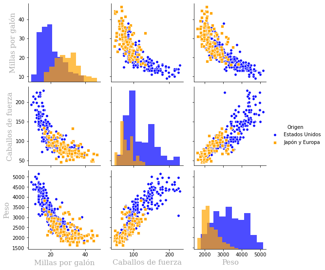

```python
fig = sns.pairplot(cars, vars=["mpg","horsepower","weight"],hue="Origen",kind="scatter",
                   diag_kind="hist",palette=["blue","orange"],
                   markers=["o", "s"],plot_kws={"s":30},diag_kws={"alpha":0.7})
axes = fig.axes.flatten()
titulos = ["Millas por galón","Caballos de fuerza","Peso"]
c = np.sqrt(len(axes))
for ax1 in np.arange(0,c):
    for ax2 in np.arange(0,c):
        ax = int(ax1*c + ax2)
        if ax2 == 0: axes[ax].set_ylabel(titulos[int(ax1)],fontdict={"family":"serif","color":"darkgrey","size":15})
        if ax1 == c-1: axes[ax].set_xlabel(titulos[int(ax2)],fontdict={"family":"serif","color":"darkgrey","size":15})
plt.show(fig)
```

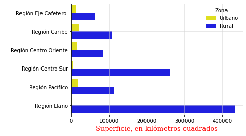

```python
fig=sns.barplot(y="Region",x="Superficie",hue="Zona",data=Municipios,estimator=sum,ci=None,
                palette=dict(Rural="blue",Urbano="yellow"))
plt.xlabel("Superficie, en kilómetros cuadrados",fontdict={"family":"serif","color":"red","size":13})
plt.ylabel(" ")
plt.legend(loc='upper right',title="Zona",frameon=False,ncol=1)
plt.grid(axis="both",color="lightgray",ls="solid",lw=0.5)
plt.show(fig)
```

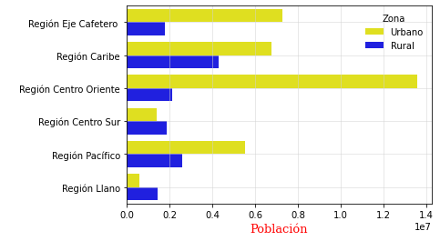

```python
fig=sns.barplot(y="Region",x="Poblacion",hue="Zona",data=Municipios,estimator=sum,ci=None,
                palette=dict(Rural="blue",Urbano="yellow"))
plt.xlabel("Población",fontdict={"family":"serif","color":"red","size":13})
plt.ylabel(" ")
plt.legend(loc='upper right',title="Zona",frameon=False,ncol=1)
plt.grid(axis="both",color="lightgray",ls="solid",lw=0.5)
plt.show(fig)
```

# Bibliografia

[figure not shown]